# Exploration of Bay Wheels ride data from August 2021

## by Elaine Chow

## Investigation Overview

> In this investigation, I explored Bay Wheels bike sharing data from August 2021. The main focus to look at were trends or patterns in ride duration (in minutes), ride distance (from starting point to ending point, not by route) and estimated ride cost, by rider type and by bike type. I also examined this data to see if there were trends or patterns depending on time: the start hour, the day of the week and the day of the month (i.e., what did the ride data look like over the entire month).

## Dataset Overview

> The cleaned dataset consisted of attributes of approximately 202,655 Bay Wheels rides, including with bike type, rider type, start date/time, end date/time, ride duration, start latitude, start longitude, end latitude, end longitude, start_datehour, end_date_hour, start_dayofweek, end_dayofweek, dist_in_km, est_ride_cost).

## Distribution of Ride Duration

> Ride duration in the dataset range from 1 minute to more than 1,000 minutes. Plotted on a logarithmic scale, the distribution of ride duration takes on a unimodal shape.

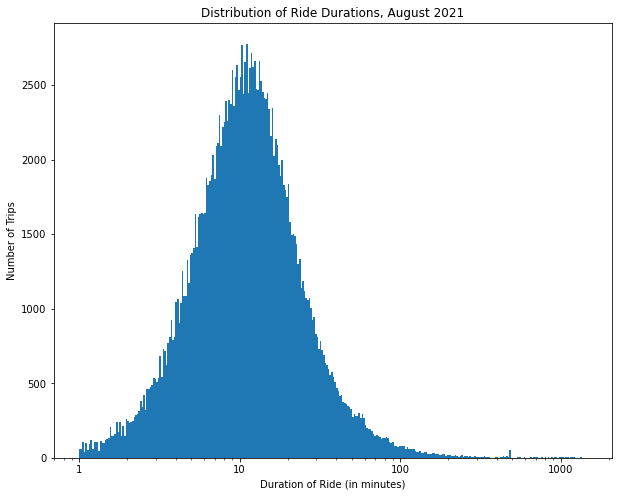

## Number of Rides Per Day, August 2021

> This line chart shows that in August 2021, overall ridership tended to dip on Mondays and peak on Saturdays.

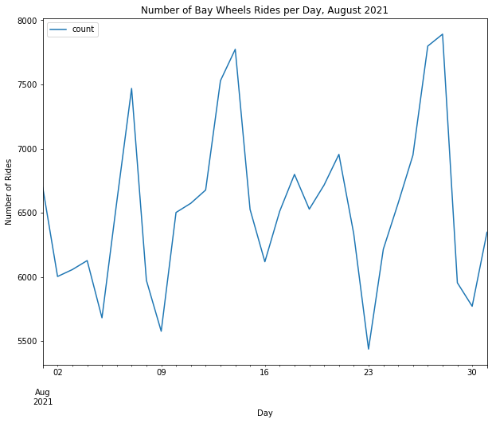

## Number of Rides Per Day by Rider Type, August 2021

> This line chart shows that in August 2021, casual riders tended to ride on Friday, Saturday and Sunday, while member riders tended to ride on weekdays.

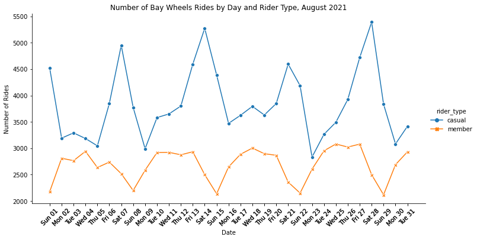

## Number of Rides Per Day by Bike Type, August 2021

> This line chart shows that in August 2021, ridership of both electric and classic bikes tended to peak over the weekend (Saturday) and dip on Monday. The number of rides on docked bikes was much lower, and tended to stay flat.

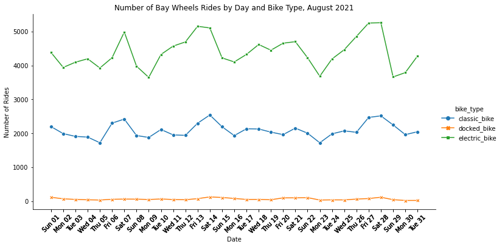

## Mean Ride Duration in Minutes by Day of the Week and Rider Type, August 2021

> This bar chart shows that the average (mean) ride duration by casual riders is greater than the average (mean) ride duration of member riders, both on weekdays and weekends. Mean ride duration for member rides is less than 15 minutes.

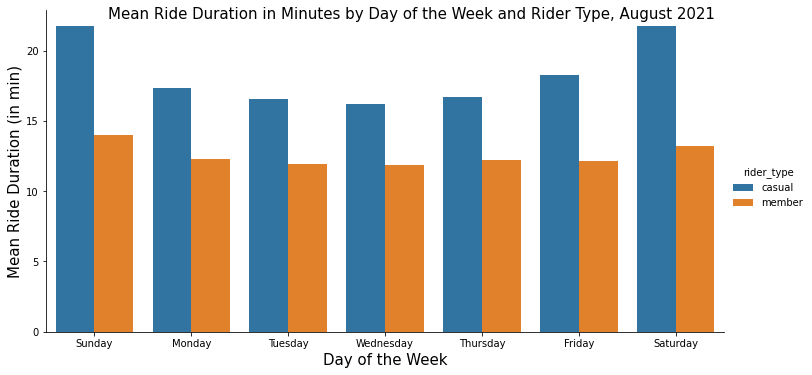